# PISA 2012

## by Sanatbek Matlatipov

## Investigation Overview

> I want to investigate how students' life and study has impact on their academic performance as well as conclude those performace.

## Dataset Overview

> PISA is a survey of students' skills and knowledge as they approach the end of compulsory education. It seems that PISA 2012 survey is about how well student is prepared for life beyond school rather than just how well student have observed school lessons. Around 510,000 students in 65 economies took part in the PISA 2012 assessment of reading, mathematics and science representing about 28 million 15-year-olds globally.

## First Group to assess

- CNT - Country code
- SUBNATIO -- Adjudicated sub-region code 7-digit code (3-digit country code + region ID + stratum ID)
- STRATUM -- Stratum ID 7-character (cnt + region ID + original stratum ID)
- OECD -- OECD country
- NC -- National Centre 6-digit Code
- SCHOOLID -- School ID 7-digit (region ID + stratum ID + 3-digit school ID)
- STIDSTD -- Student ID
- ST01Q01 -- International Grade
- ST02Q01 -- National Study Programme
- ST03Q01 -- Birth - Month
- ST03Q02 -- Birth -Year
- ST04Q01 -- Gender
- ST05Q01 -- Attend <ISCED 0>
- ST06Q01 -- Age at <ISCED 1>
- ST07Q01 -- Repeat - <ISCED 1>
- ST07Q02 -- Repeat - <ISCED 2>
- ST07Q03 -- Repeat - <ISCED 3>
- ST08Q01 -- Truancy - Late for School
- ST09Q01 -- Truancy - Skip whole school day
- ST115Q01 -- Truancy - Skip classes within school day

## Second Group to assess

- T11Q01 -- At Home - Mother
- ST11Q02 -- At Home - Father
- ST11Q03 -- At Home - Brothers
- ST11Q04 -- At Home - Sisters
- ST11Q05 -- At Home - Grandparents
- ST11Q06 -- At Home - Others
- ST13Q01 -- Mother -Highest Schooling
- ST14Q01 -- Mother Qualifications - ISCED level 6
- ST14Q02 -- Mother Qualifications - ISCED level 5A
- ST14Q03 -- Mother Qualifications - ISCED level 5B
- ST14Q04 -- Mother Qualifications - ISCED level 4
- ST15Q01 -- Mother Current Job Status
- ST17Q01 -- Father Highest Schooling
- ST18Q01 -- Father Qualifications - <ISCED level 6>
- ST18Q02 -- Father Qualifications - <ISCED level 5A>
- ST18Q03 -- Father Qualifications - <ISCED level 5B>
- ST18Q04 -- Father Qualifications - <ISCED level 4>
- ST19Q01 -- Father Current Job Status

## Third Group to assess

- ST20Q01 -- Country of Birth International - Self
- ST20Q02 -- Country of Birth International - Mother
- ST20Q03 -- Country of Birth International - Father
- ST21Q01 -- Age of arrival in country of test
- ST25Q01 -- International Language at Home
- ST26Q01 -- Possessions - desk
- ST26Q02 -- Possessions - own room
- ST26Q03 -- Possessions - study place
- ST26Q04 -- Possessions - computer
- ST26Q05 -- Possessions - software
- ST26Q06 -- Possessions - Internet
- ST26Q07 -- Possessions - literature
- ST26Q08 -- Possessions - poetry
- ST26Q09 -- Possessions - art

## Third Group to assess (cont.)

- ST26Q10 -- Possessions - textbooks
- ST26Q11 -- Possessions - technical reference books
- ST26Q12 -- Possessions - dictionary
- ST26Q13 -- Possessions - dishwasher
- ST26Q14 -- Possessions - DVD
- ST26Q15 -- Possessions - Country item 1
- ST26Q16 -- Possessions - Country item 2
- ST26Q17 -- Possessions - Country item 3
- ST27Q01 -- How many - cellular phones
- ST27Q02 -- How many - televisions
- ST27Q03 -- How many - computers
- ST27Q04 -- How many - cars
- ST27Q05 -- How many - rooms bath or shower
- ST28Q01 -- How many books at home

### Qulaity and Tideness issues

Following quality issues I found for data wrangling process..

- `Florida (USA)`, `Connecticut (USA)`, `Massachusetts (USA)` should be changed to `USA` and `Perm(Russian Federation)` to `Russian Federation`
- Country's full names should be changed to three character code
- `ST07Q01`, `ST07Q02`, `ST07Q03` will be merged to one column as `repeat_particpation`. Most frequent one will be chosen.Then, delete the columns above.
- `ST11Q01` and `ST11Q02` will be changed to 0 and 1, if it is `nan` change it to the 1
- `ST14Q01`, `ST14Q02`, `ST14Q03` and `ST14Q04` merge tables to one column as `mother_qualification`. Most frequent one will be chosen. Then, delete the columns above
- `ST18Q01`, `ST18Q02`, `ST18Q03` and `ST18Q04` merge tables to one column as `father_qualification`. Most frequent one will be chosen. Then, delete the columns above

### Qulaity and Tideness issues

- 'PV1MATH', 'PV2MATH', 'PV3MATH', 'PV4MATH', 'PV5MATH' - get the average value and delete columns
- 'PV1READ', 'PV2READ', 'PV3READ', 'PV4READ', 'PV5READ' - get the average value and delete columns
- 'PV1SCIE', 'PV2SCIE', 'PV3SCIE', 'PV4SCIE', 'PV5SCIE' - get the average value and delete columns
- Work ethic common columns should be selected and melt to rows and count inside for heatmap
- columnn name should be changed to readable format

## Univariate Exploration

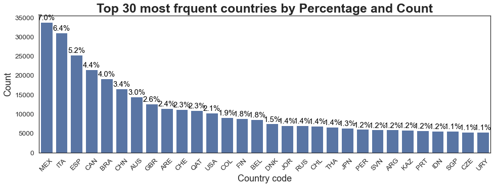

The top 3 most frequent countries are `Mexico`, `Italy` and `Spain`. Next, I am going to discover the gender distribution of the pisa dataset. Because, I am also planning to explore if boy student study better than girl student or vice-versa.

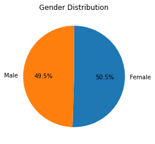

Percentage of gender distribution is almost same. So, I can compare boys and girls without having simpson's paradox. Now, let's see if gender has imapct on average academic score of student's.

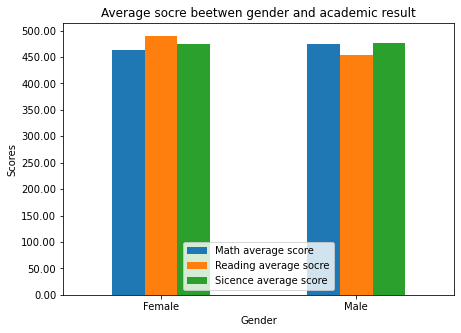

Average academic scores of both genders are almost same. However, If we look deeply, we can only see that reading for female is slightly higher than male and on the other hand, male are slightly betterr in mathematics than female. Next, I am going to determine Plausable average score dsitribution to determine, it the scores are normally distributed.

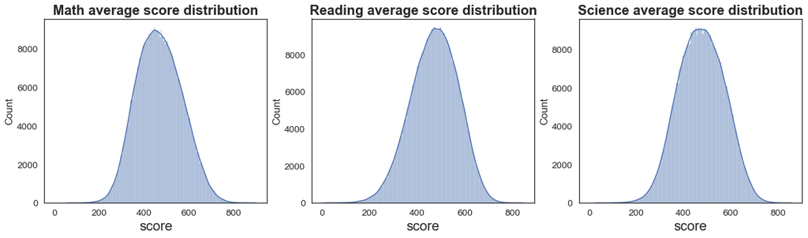

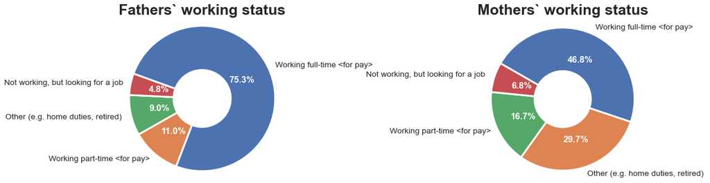

More fathers' have full-time job than mothers. It seems mothers have more home duties than fathers. Unemployment rate is low for both of the genders which is very good. Now, let's check theit `education level`

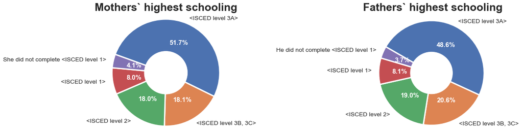

The highest proportion for both gender corresponds to International Standard Classification of Education of **level 3A** which is **upper secondary education**. Next, let's determine birth country of parent's and self

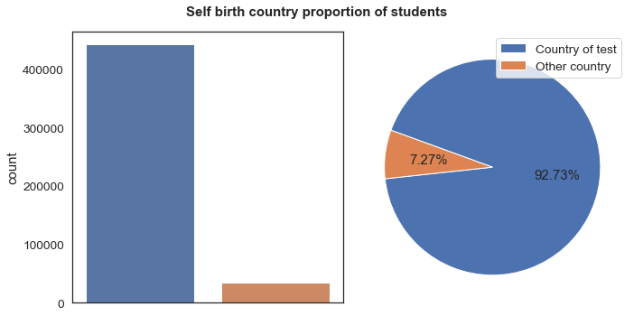

It is obvious from above that, most of students are from country where PISA test happened(**93% vs 7%**).

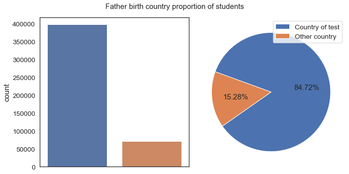

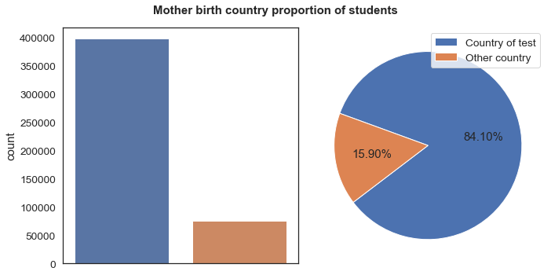

We can see that for both father and mother who came as immigrant slightly higher than their children.

[figure not shown]

Most of the parents are from test country

## Bivariate Exploration

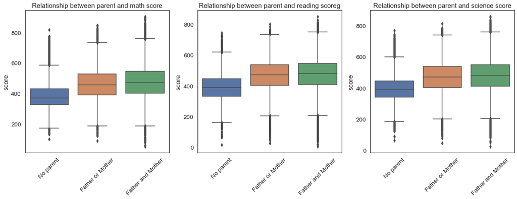

It seems above that, student who has at least `Father/Mother` is likely to get higher score than `No parent` situation. This is proof that parents companionship play an essential role. Next, I am going to explore relationship between birth country and score of student

# Relationship between birth country and score of student

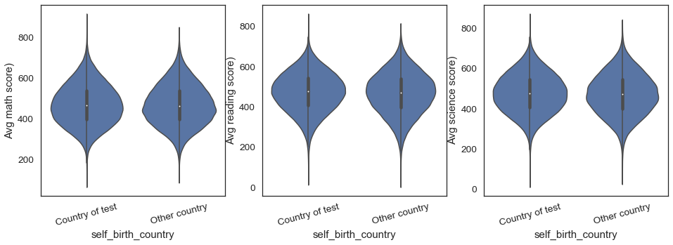

When I observered relationship between birth country and average score of students with math, science and reading, it is obvious that scoring distribution is same for `country of test` and `other country`

## Multivariate Exploration

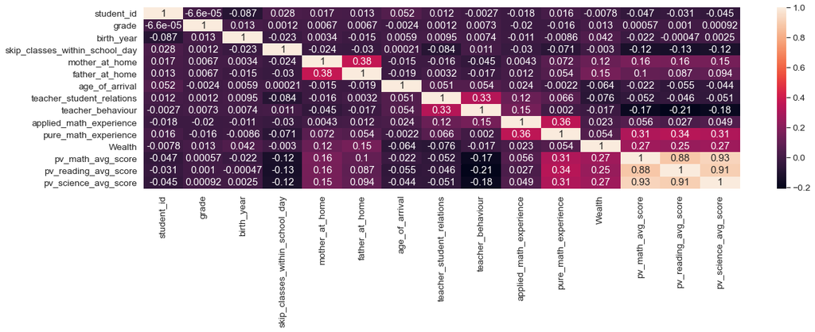

math_average_score and reading_average_score/science_average_score has a strong positvice correlation. Subjects have a high positive correlation between each other. Teacher behavior has a negative relationship with scores